# homework #9

Maryam Nouri-Aiin

2024-03-27

Organizing Code With Structured Programming Use the code that you worked on in Homework #7 (creating fake data sets), and re-organize it following the principles of structured programming. Do all the work in a single chunk in your R markdown file, just as if you were writing a single R script. Start with all of your annotated functions, preliminary calls, and global variables. The program body should be only a few lines of code that call the appropriate functions and run them in the correct order. Make sure that the output from one function serves as the input to the next. You can either daisy-chain the functions or write separate lines of code to hold elements in temporary variables and pass them along.

```r
source("functions.R", local = knitr::knit_global())
```

```
##             Df Sum Sq Mean Sq F value Pr(>F)
## group        1  422.9   422.9     298 <2e-16 ***
## Residuals   58   82.3     1.4
## ---
## Signif. codes:  0 '***' 0.001 '**' 0.01 '*' 0.05 '.' 0.1 ' ' 1
```

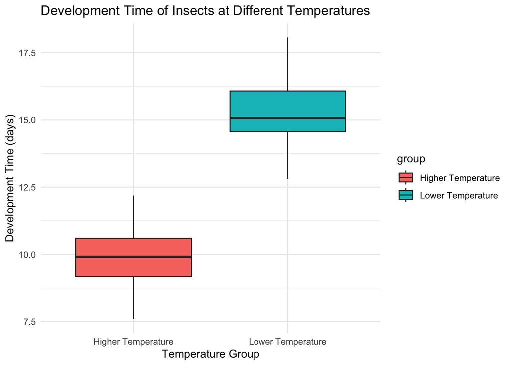

```
## Iteration 1 :
##             Df Sum Sq Mean Sq F value Pr(>F)
## group        1  351.0   351.0   252.5 <2e-16 ***
## Residuals   58   80.6     1.4
## ---
## Signif. codes:  0 '***' 0.001 '**' 0.01 '*' 0.05 '.' 0.1 ' ' 1
## Iteration 2 :
##             Df Sum Sq Mean Sq F value Pr(>F)
## group        1  444.3   444.3   236.8 <2e-16 ***
## Residuals   58  108.8     1.9
## ---
## Signif. codes:  0 '***' 0.001 '**' 0.01 '*' 0.05 '.' 0.1 ' ' 1
## Iteration 3 :
##             Df Sum Sq Mean Sq F value Pr(>F)
## group        1  353.6   353.6   241.4 <2e-16 ***
## Residuals   58   85.0     1.5
## ---
## Signif. codes:  0 '***' 0.001 '**' 0.01 '*' 0.05 '.' 0.1 ' ' 1
## Iteration 4 :
##             Df Sum Sq Mean Sq F value Pr(>F)
## group        1  439.7   439.7   275.8 <2e-16 ***
## Residuals   58   92.5     1.6
## ---
## Signif. codes:  0 '***' 0.001 '**' 0.01 '*' 0.05 '.' 0.1 ' ' 1
## Iteration 5 :
##             Df Sum Sq Mean Sq F value Pr(>F)
## group        1  339.6   339.6   156.9 <2e-16 ***
## Residuals   58  125.6     2.2
## ---
## Signif. codes:  0 '***' 0.001 '**' 0.01 '*' 0.05 '.' 0.1 ' ' 1
## Iteration 6 :
##             Df Sum Sq Mean Sq F value Pr(>F)
## group        1  317.5   317.5   215.8 <2e-16 ***
## Residuals   58   85.3     1.5
## ---
## Signif. codes:  0 '***' 0.001 '**' 0.01 '*' 0.05 '.' 0.1 ' ' 1
```

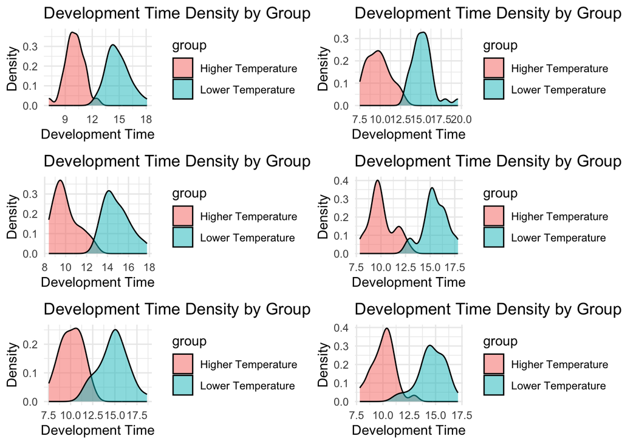

```
## [1] "Minimum detectable effect size (Cohen's d): 0.01"
##
##      Two-sample t test power calculation
##
##               n = 2.513095
##               d = 3.779645
##       sig.level = 0.05
##           power = 0.8
##     alternative = two.sided
##
## NOTE: n is number in *each* group
##
## [1] 2.513095
```

```
##             Df Sum Sq Mean Sq F value Pr(>F)
## group        1  422.9   422.9     298 <2e-16 ***
## Residuals   58   82.3     1.4
## ---
## Signif. codes:  0 '***' 0.001 '**' 0.01 '*' 0.05 '.' 0.1 ' ' 1
```

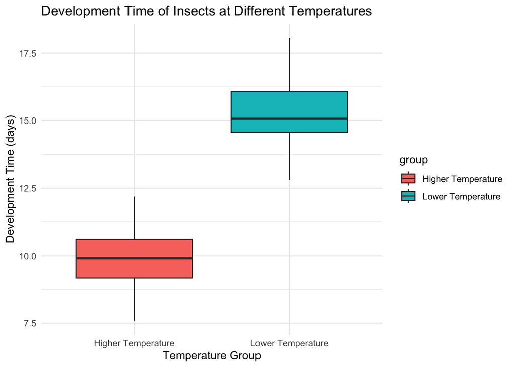

```r
anova_boxplot()
```

```r
multiple_iterations()
```

```
## Iteration 1 :
##             Df Sum Sq Mean Sq F value Pr(>F)
## group        1  463.2   463.2     356 <2e-16 ***
## Residuals   58   75.5     1.3
## ---
## Signif. codes:  0 '***' 0.001 '**' 0.01 '*' 0.05 '.' 0.1 ' ' 1
## Iteration 2 :
##             Df Sum Sq Mean Sq F value Pr(>F)
## group        1  356.6   356.6     193 <2e-16 ***
## Residuals   58  107.2     1.8
## ---
## Signif. codes:  0 '***' 0.001 '**' 0.01 '*' 0.05 '.' 0.1 ' ' 1
## Iteration 3 :
##             Df Sum Sq Mean Sq F value Pr(>F)
## group        1  356.3   356.3   260.7 <2e-16 ***
## Residuals   58   79.3     1.4
## ---
## Signif. codes:  0 '***' 0.001 '**' 0.01 '*' 0.05 '.' 0.1 ' ' 1
## Iteration 4 :
##             Df Sum Sq Mean Sq F value Pr(>F)
## group        1  415.5   415.5   344.4 <2e-16 ***
## Residuals   58   70.0     1.2
## ---
## Signif. codes:  0 '***' 0.001 '**' 0.01 '*' 0.05 '.' 0.1 ' ' 1
## Iteration 5 :
##             Df Sum Sq Mean Sq F value Pr(>F)
## group        1  328.5   328.5   183.2 <2e-16 ***
## Residuals   58  104.0     1.8
## ---
## Signif. codes:  0 '***' 0.001 '**' 0.01 '*' 0.05 '.' 0.1 ' ' 1
## Iteration 6 :
##             Df Sum Sq Mean Sq F value Pr(>F)
## group        1  308.9   308.9   154.6 <2e-16 ***
## Residuals   58  115.9     2.0
## ---
## Signif. codes:  0 '***' 0.001 '**' 0.01 '*' 0.05 '.' 0.1 ' ' 1
```

[figure not shown]

```r
min_effect_size()
```

```
## [1] "Minimum detectable effect size (Cohen's d): 0.01"
```

```r
min_sample_size()
```

```
##
##      Two-sample t test power calculation
##
##               n = 2.513095
##               d = 3.779645
##       sig.level = 0.05
##           power = 0.8
##     alternative = two.sided
##
## NOTE: n is number in *each* group
##
## [1] 2.513095
```

```r
min_sample_size()
```

```
##
##      Two-sample t test power calculation
##
##               n = 2.513095
##               d = 3.779645
##       sig.level = 0.05
##           power = 0.8
##     alternative = two.sided
##
## NOTE: n is number in *each* group
##
## [1] 2.513095
```

Once your code is up and working, modify your program to do something else: record a new summary variable, code a new statistical analysis, or create a different set of random variables or output graph. Do not rewrite any of your existing functions. Instead, copy them, rename them, and then modify them to do new things. Once your new functions are written, add some more lines of program code, calling a mixture of your previous functions and your new functions to get the job done.

```r
# New Function: Calculate confidence interval for the difference in means
ci_diff <- function() {
  sd1 <- sqrt(var_high_temp)
  mean1 <- mean_high_temp
  sd2 <- sqrt(var_low_temp)
  mean2 <- mean_low_temp

  t.test(rnorm(sample_size, mean1, sd1), rnorm(sample_size, mean2, sd2), var.equal = TRUE)$conf.int
}

# Call the functions
ci_diff()
```

```
## [1] -5.661166 -4.513737
## attr(,"conf.level")
## [1] 0.95
```

```r
min_sample_size()
```

```
##
##      Two-sample t test power calculation
##
##               n = 2.513095
##               d = 3.779645
##       sig.level = 0.05
##           power = 0.8
##     alternative = two.sided
##
## NOTE: n is number in *each* group
##
## [1] 2.513095
```

Optional. If time permits and you have the skills, try putting your program inside of a for loop and repeat the analysis with a different stochastic data set (each time you call a function that invokes the random number generator, it will create a new set of data for you to process). Can you create a data structure to store the summary statistics created in each pass through the loop? If not, your program will work, but it will only show the results from the final replicate (the previous results will be written over each time you traverse the loop).

```r
# Function to perform multiple iterations of analysis
multiple_iterations <- function(num_iterations) {
  results <- list()

  for (i in 1:num_iterations) {
    # Generate new data for each iteration
    high_temp_data <- high_temp()
    low_temp_data <- low_temp()
    df <- rbind(high_temp_data, low_temp_data)

    # Perform ANOVA and store summary statistics
    anova_result <- aov(development_time ~ group, data = df)
    results[[i]] <- summary(anova_result)
  }

  return(results)
}

# Function to print summary statistics from multiple iterations
print_summary_statistics <- function(summary_stats) {
  for (i in 1:length(summary_stats)) {
    cat("Iteration", i, ":\n")
    print(summary_stats[[i]])
  }
}

# Number of iterations
num_iterations <- 5

# Perform multiple iterations of analysis
summary_stats <- multiple_iterations(num_iterations)

# Print summary statistics
print_summary_statistics(summary_stats)
```

```
## Iteration 1 :
##             Df Sum Sq Mean Sq F value Pr(>F)
## group        1  316.4   316.4   183.7 <2e-16 ***
## Residuals   58   99.9     1.7
## ---
## Signif. codes:  0 '***' 0.001 '**' 0.01 '*' 0.05 '.' 0.1 ' ' 1
## Iteration 2 :
##             Df Sum Sq Mean Sq F value Pr(>F)
## group        1  277.3   277.3   138.7 <2e-16 ***
## Residuals   58  115.9     2.0
## ---
## Signif. codes:  0 '***' 0.001 '**' 0.01 '*' 0.05 '.' 0.1 ' ' 1
## Iteration 3 :
##             Df Sum Sq Mean Sq F value Pr(>F)
## group        1  426.1   426.1   235.6 <2e-16 ***
## Residuals   58  104.9     1.8
## ---
## Signif. codes:  0 '***' 0.001 '**' 0.01 '*' 0.05 '.' 0.1 ' ' 1
## Iteration 4 :
##             Df Sum Sq Mean Sq F value Pr(>F)
## group        1  402.3   402.3   203.1 <2e-16 ***
## Residuals   58  114.9     2.0
## ---
## Signif. codes:  0 '***' 0.001 '**' 0.01 '*' 0.05 '.' 0.1 ' ' 1
## Iteration 5 :
##             Df Sum Sq Mean Sq F value Pr(>F)
## group        1  332.6   332.6   223.3 <2e-16 ***
## Residuals   58   86.4     1.5
## ---
## Signif. codes:  0 '***' 0.001 '**' 0.01 '*' 0.05 '.' 0.1 ' ' 1
```